> **Objectives**  
> * Introduction to Bioinformatic workflows with snakemake * Visualize read quality  
> * Improve/Salvage samples with Quality filters and trimmed reads

# Βιοπληροφορικές ροές εργασίας

Όταν εργαζόμαστε με δεδομένα αλληλούχησης, τα αρχεία που λαμβάνουμε θα πρέπει να περάσουν από αρκετά διαφορετικά εργαλεία για να παράγουν το επιθυμητό τελικό αποτέλεσμα. Η εκτέλεση αυτού του συνόλου εργαλείων με μια συγκεκριμένη σειρά αναφέρεται συνήθως ως *ροή εργασίας* (*workflow* ή *pipeline*).

Σήμερα θα μάθουμε να συνδυάσουμε πολλά εργαλεία σε μια ροή εργασίας χρησιμοποιώντας το εργαλείο *Snakemake*. Το Snakemake είναι ένα σύστημα διαχείρισης ροής εργασίας που επιτρέπει τη δημιουργία επαναλήψιμων αναλύσεων δεδομένων. Είναι ιδιαίτερα χρήσιμο για τις ροές εργασιών βιοπληροφορικής, καθώς επιτρέπει στον χρήστη να ορίσει τη σειρά εκτέλεσης των εργαλείων και τις εξαρτήσεις μεταξύ τους.

Σήμερα θα δημιουργήσουμε μια ροή εργασίας για την ανάλυση δεδομένων αλληλούχησης. Θα ξεκινήσουμε με την αξιολόγηση της ποιότητας των αρχείων FASTQ μας, θα εφαρμόσουμε φίλτρα ποιότητας και τέλος θα αφαιρέσουμε τις αλληλουχίες χαμηλής ποιότητας.

Για τη σημερινή άσκηση θα χρησιμοποιήσουμε τα αρχεία FASTQ που βρίσκονται στον φάκελο `raw_reads` του αποθετηρίου. Τα αρχεία αυτά περιέχουν αναγνώσεις από δύο δείγματα, `A` και `B`.

Ας ξεκινήσουμε!

# Λίγα λόγια για τα αρχεία FASTQ

Τα αρχεία FASTQ χρησιμοποιούνται για την αποθήκευση αναγνώσεων αλληλούχησης (sequencing reads). Κάθε ανάγνωση αποτελείται από τέσσερα μέρη: 1. Πληροφορίες για την αλληλουχία, που ξεκινά με το σύμβολο `@`. 2. Η αλληλουχία DNA. 3. Το σύμβολο `+` και ορισμένες φορές πληροφορίες για την αλληλουχία ομοίως με τη γραμμή 1. 4. Η ποιότητα κάθε βάσης της αλληλουχίας. Περιέχει τόσους χαρακτήρες όσους και η γραμμή 2.

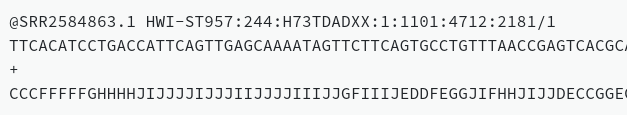

fastq_file

# Ενεργοποίηση του περιβάλλοντος εργασίας

Στο τερματικό μας, ενεργοποιούμε το περιβάλλον εργασίας που δημιουργήσαμε.

```bash
conda activate bge_course
```

Μεταβαίνουμε στον φάκελο της άσκησης.

```bash
cd snakemake_tutorial
```

# Εισαγωγή στο Snakemake

Θα ορίσουμε τη ροή εργασίας μας σε ένα αρχείο που θα ονομάσουμε `Snakefile`. Αυτό το αρχείο θα περιέχει τους κανόνες που καθορίζουν τη σειρά εκτέλεσης των εργαλείων, τα αρχεία εισόδου και εξόδου και τις παραμέτρους που θα περάσουν στα εργαλεία.

Αρχικά, δημιουργούμε το αρχείο `Snakefile`.

```bash
touch Snakefile
```

Μπορούμε να επεξεργαστούμε το αρχείο `Snakefile` χρησιμοποιώντας έναν επεξεργαστή κειμένου της επιλογής μας στο τερματικό (π.χ. nano). Για να γίνει πιο εύκολο, θα ανοίξουμε το `Snakefile` σε έναν γραφικό επεξεργαστή κειμένου. Αν είστε σε Windows μπορείτε να χρησιμοποιήσετε το Notepad ή το Visual Studio Code. Καθώς θα χρησιμοποιήσουμε το RStudio για το υπόλοιπο του εργαστηρίου, μπορούμε επίσης να το χρησιμοποιήσουμε για να επεξεργαστούμε το `Snakefile`.

# Βήμα 1: Το πρώτο μας Snakemake rule - Quality control for raw sequences

Ο πρώτος μας κανόνας στο snakemake θα είναι να τρέξουμε το FastQC στα δεδομένα αλληλούχησης μας. Το FastQC είναι ένα εργαλείο που παρέχει έναν απλό τρόπο για να κάνουμε έλεγχους ποιότητας στα αρχεία αλληλούχησης. Παράγει μια αναφορά που δίνει μια επισκόπηση της ποιότητας των δεδομένων μας.

Ας ξεκινήσουμε με τον πρώτο μας κανόνα Snakemake. Στο αρχείο `Snakefile` προσθέτουμε τον παρακάτω κανόνα:

```python
rule fastqc_raw_reads:
    input:
        "raw_reads/A.fastq"
    params:
        "fastqc_untrimmed_reads"
    output:
        "fastqc_untrimmed_reads/A_fastqc.html",
    shell:
        "fastqc {input} -o {params}"
```

Όταν εκτελείται μια ροή εργασίας, το Snakemake προσπαθεί να δημιουργήσει τα **target** αρχεία. Τα target αρχεία μπορούν να καθοριστούν μέσω της γραμμής εντολών. Εκτελώντας

```bash
snakemake -n -p fastqc_untrimmed_reads/A_fastqc.html
```

στον φάκελο που περιέχει το Snakefile, λέμε στο Snakemake να δημιουργήσει το αρχείο στόχο `fastqc_untrimmed_reads/A_fastqc.html`. Καθώς χρησιμοποιήσαμε την παράμετρο `-n` (ή `--dry-run`), το Snakemake θα εμφανίσει μόνο το σχέδιο εκτέλεσης αντί να εκτελέσει πραγματικά τα βήματα. Η παράμετρος `-p` ενημερώνει το Snakemake να εμφανίσει επίσης την τελική εντολή για επεξήγηση.

Μπορούμε να εκτελέσουμε τη ροή εργασίας μας με:

```bash
snakemake --cores 1 fastqc_untrimmed_reads/A_fastqc.html
```

Όταν εκτελούμε μια ροή εργασίας, πρέπει να καθορίσουμε τον αριθμό των πυρήνων που θα χρησιμοποιηθούν. Σημειώστε ότι, μετά την ολοκλήρωση της παραπάνω εντολής, το Snakemake δεν θα προσπαθήσει να δημιουργήσει ξανά το αρχείο `fastqc_untrimmed_reads/A_fastqc.html`, επειδή υπάρχει ήδη. Το Snakemake **εκτελεί εκ νέου εργασίες μόνο εάν ένα από τα αρχεία εισόδου είναι νεότερο από ένα από τα αρχεία εξόδου ή ένα από τα αρχεία εισόδου θα ενημερωθεί από άλλη εργασία**.

Προσπαθήστε να εκτελέσετε ξανά την παραπάνω εντολή. Τι συμβαίνει;

# Step 2: Γενίκευση κανόνων

Ο παραπάνω κανόνας δουλεύει για ένα αρχείο. Αν θέλουμε να τον επαναχρησιμοποιήσουμε για πολλά αρχεία, θα πρέπει να τον γενικεύσουμε. Αυτό μπορεί να γίνει με τη χρήση wildcards. Στον παραπάνω κανόνα θα αντικαταστήσουμε το δείγμα `A` με μια μεταβλητή `sample`.

```python
rule fastqc_raw_reads:
    input:
        "raw_reads/{sample}.fastq"
    params:
        "fastqc_untrimmed_reads"
    output:
        "fastqc_untrimmed_reads/{sample}_fastqc.html",
    shell:
        "fastqc {input} -o {params}"
```

Έπειτα μπορούμε να εκτελέσουμε τη ροή εργασίας μας για τα δείγματα `A` και `B` με την εντολή:

```bash
snakemake --cores 1 -p fastqc_untrimmed_reads/A_fastqc.html fastqc_untrimmed_reads/B_fastqc.html
```

## Αξιολόγηση των αποτελεσμάτων του FastQC

Μετά την ολοκλήρωση της εκτέλεσης του FastQC, μπορούμε να δούμε τα αποτελέσματα στο αρχείο HTML που δημιουργήθηκε. Ανοίξτε το αρχείο με τον προεπιλεγμένο περιηγητή σας (firefox, chrome, etc) και εξετάστε τα διάφορα τμήματα της αναφοράς.

Τα τμήματα της αναφοράς FastQC είναι: - **Per tile sequence quality**: Τα μηχανήματα στα οποία γίνεται η αλληλούχηση αποτελούνται από tiles (πλακίδια). Αυτό το τμήμα της αναφοράς ελέγχει την ποιότητα των αναγνώσεων ανά tile. - **Per sequence quality scores**: Κατανομή της ποιότητας των αναγνώσεων. - **Per base sequence content**: Η συχνότητα εμφάνισης κάθε βάσης σε κάθε θέση της ανάγνωσης. - **Per sequence GC content**: Κατανομή του ποσοστού GC. - **Per base N content**: Το ποσοστό των αναγνώσεων που περιέχουν “N” σε κάθε θέση της ανάγνωσης. - **Sequence length distribution**: Κατανομή του μήκους των αναγνώσεων. - **Sequence duplication levels**: Το ποσοστό των αναγνώσεων που είναι διπλότυπες. - **Overrepresented sequences** : Οι αναγνώσεις που είναι υπερ-αντιπροσωπευμένες. - **Adapter content** : Που εντοπίζονται οι αντάπτορες στις αναγνώσεις.

# Βήμα 3: FASTQ trimming

Ορισμένα από τα δείγματά μας απέτυχαν σε κάποια στατιστικά ποιότητας. Αυτό δεν σημαίνει, ωστόσο, ότι πρέπει να απορριφθούν. Σε αυτό το στάδιο θα αφαιρέσουμε ορισμένες αλληλουχίες χαμηλής ποιότητας.

Θα χρησιμοποιήσουμε το πρόγραμμα Trimmomatic με τις εξής παραμέτρους: * **SLIDINGWINDOW**:<windowSize>:<requiredQuality>

```
* windowSize: specifies the number of bases to average across
* requiredQuality: specifies the average quality required.
```

- **MINLEN**:<length>
  - length: Specifies the minimum length of reads to be kept.

Στο Snakefile μας θα προσθέσουμε έναν νέο κανόνα για την επεξεργασία των αρχείων FASTQ με το Trimmomatic.

```python
rule trim_reads:
    input:
        "raw_reads/{sample}.fastq"
    output:
        "trimmed_reads/{sample}_trim.fastq"
    shell:
        "trimmomatic SE {input} {output} SLIDINGWINDOW:4:20 MINLEN:25"
```

Επιπλέον θα προσθέσουμε έναν κανόνα για τον έλεγχο ποιότητας των αρχείων FASTQ που έχουν υποστεί επεξεργασία.

```python
rule fastqc_trimmed_reads:
    input:
        "trimmed_reads/{sample}_trim.fastq"
    params:
        "fastqc_trimmed_reads"
    output:
        "fastqc_trimmed_reads/{sample}_trim_fastqc.html",
    shell:
        "fastqc {input} -o {params}"
```

Τώρα μπορούμε να εκτελέσουμε τη ροή εργασίας με την εντολή:

```bash
snakemake --cores 1 -p fastqc_trimmed_reads/A_trim_fastqc.html fastqc_trimmed_reads/B_trim_fastqc.html
```

## MultiQC

Όταν έχουμε πολλά αρχεία, θα πρέπει να ελέγξουμε και πολλές αναφορές FastQC. Θα χρησιμοποιήσουμε το εργαλείο MultiQC για να συγκεντρώσουμε τις αναφορές FastQC σε ένα αρχείο.

Για να προσθέσουμε τον κανόνα MultiQC στο Snakefile μας:

```python
rule multiqc:
    input:
        expand("fastqc_trimmed_reads/{sample}_trim_fastqc.html", sample=SAMPLES)
    params:
        "fastqc_trimmed_reads"
    output:
        "multiqc_report.html"
    shell:"multiqc {params} --force"
```

Στον κανόνα αυτό, το `expand` επεκτείνει το string `"fastqc_trimmed_reads/{sample}_trim_fastqc.html"` για κάθε δείγμα στη λίστα `SAMPLES`. Η λίστα `SAMPLES` θα πρέπει να οριστεί στην αρχή του Snakefile.

Προσθέτουμε λοιπόν την παρακάτω γραμμή στην αρχή του Snakefile:

```python
SAMPLES = ["A", "B"]
```

Μπορούμε να οπτικοποιήσουμε τη ροή εργασίας μας με την εντολή:

```bash
snakemake multiqc_report.html --dag | dot -Tpng > dag.png
```

*Ανοίξτε το αρχείο `dag.png` για να δείτε το γράφημα της ροής εργασίας.*

Τώρα μπορούμε να εκτελέσουμε τη ροή εργασίας μας με την εντολή:

```bash
snakemake --cores 1 multiqc_report.html
```

Μετά την ολοκλήρωση της εκτέλεσης, μπορούμε να δούμε την αναφορά MultiQC στο αρχείο `multiqc_report.html`.

## Understanding FASTQ file QC results

### Sequence Quality histograms

The y-axis on the graph shows the quality scores. The higher the score, the better the base call. The background of the graph divides the y axis into very good quality calls (green), calls of reasonable quality (orange), and calls of poor quality (red). The quality of calls on most platforms will degrade as the run progresses, so it is common to see base calls falling into the orange area towards the end of a read.

[figure not shown]

fastqc_quality_hist

### Per Sequence Quality Scores

The per sequence quality score report allows you to see if a subset of your sequences have universally low quality values. It is often the case that a subset of sequences will have universally poor quality, however these should represent only a small percentage of the total sequences.

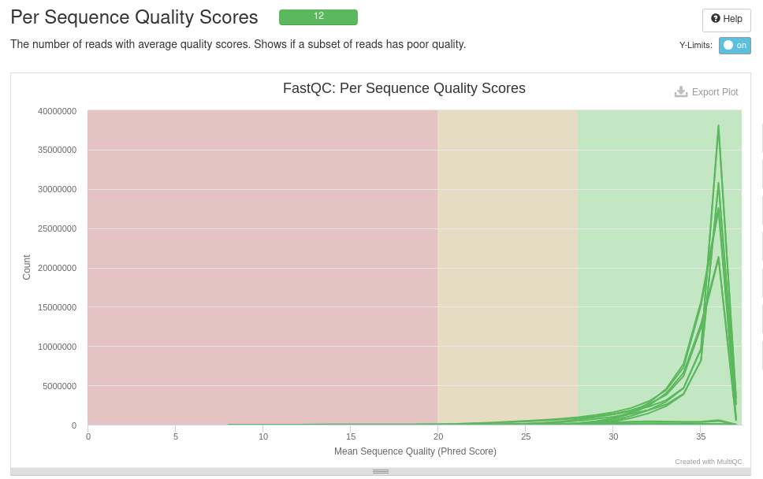

### Per Base Sequence Content

To enable multiple samples to be shown in a single plot, the base composition data is shown as a heatmap. The colours represent the balance between the four bases: an even distribution should give an even muddy brown colour. Hover over the plot to see the percentage of the four bases under the cursor.

Per Base Sequence Content plots out the proportion of each base position in a file for which each of the four normal DNA bases has been called.

In a random library you would expect that there would be little to no difference between the different bases of a sequence run, so the lines in this plot should run parallel with each other. The relative amount of each base should reflect the overall amount of these bases in your genome, but in any case they should not be hugely imbalanced from each other.

It’s worth noting that some types of library will always produce biased sequence composition, normally at the start of the read. Libraries produced by priming using random hexamers (including nearly all RNA-Seq libraries) and those which were fragmented using transposases inherit an intrinsic bias in the positions at which reads start. This bias does not concern an absolute sequence, but instead provides enrichement of a number of different K-mers at the 5’ end of the reads. Whilst this is a true technical bias, it isn’t something which can be corrected by trimming and in most cases doesn’t seem to adversely affect the downstream analysis.

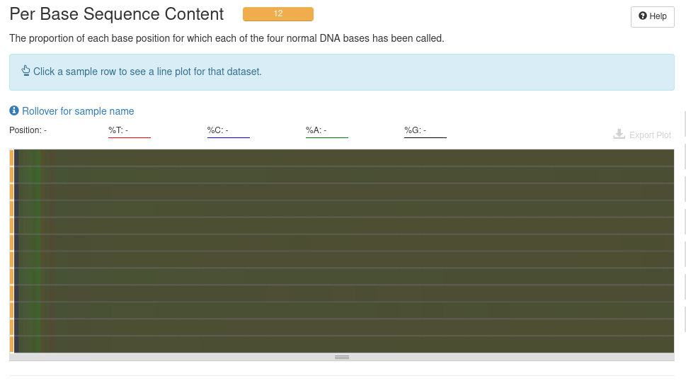

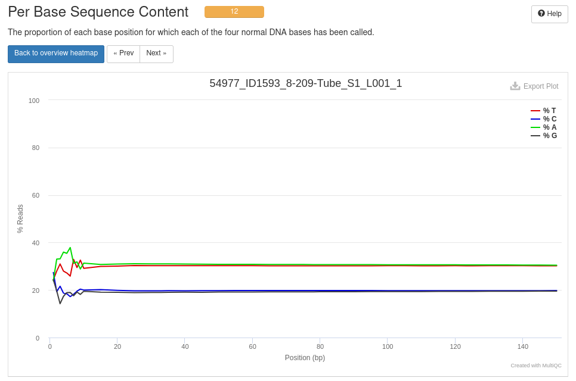

This module measures the GC content across the whole length of each sequence in a file and compares it to a modelled normal distribution of GC content.

In a normal random library you would expect to see a roughly normal distribution of GC content where the central peak corresponds to the overall GC content of the underlying genome. Since we don’t know the the GC content of the genome the modal GC content is calculated from the observed data and used to build a reference distribution.

An unusually shaped distribution could indicate a contaminated library or some other kinds of biased subset. A normal distribution which is shifted indicates some systematic bias which is independent of base position. If there is a systematic bias which creates a shifted normal distribution then this won’t be flagged as an error by the module since it doesn’t know what your genome’s GC content should be.

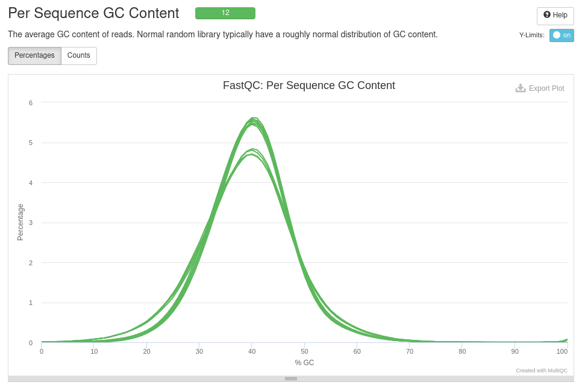

Per Sequence GC Content

### Per Base N Content

If a sequencer is unable to make a base call with sufficient confidence then it will normally substitute an N rather than a conventional base call. This graph shows the percentage of base calls at each position for which an N was called.

It’s not unusual to see a very low proportion of Ns appearing in a sequence, especially nearer the end of a sequence. However, if this proportion rises above a few percent it suggests that the analysis pipeline was unable to interpret the data well enough to make valid base calls.

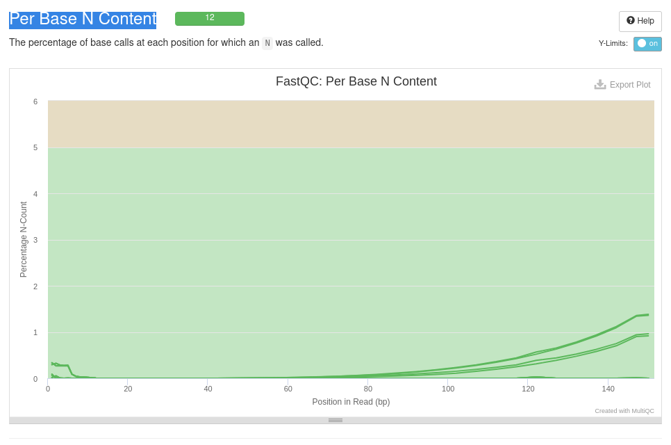

### Sequence Length Distribution

Some high throughput sequencers generate sequence fragments of uniform length, but others can contain reads of wildly varying lengths. Even within uniform length libraries some pipelines will trim sequences to remove poor quality base calls from the end.

This module generates a graph showing the distribution of fragment sizes in the file which was analysed. In many cases this will produce a simple graph showing a peak only at one size, but for variable length FastQ files this will show the relative amounts of each different size of sequence fragment. Warning

This module will raise a warning if all sequences are not the same length.

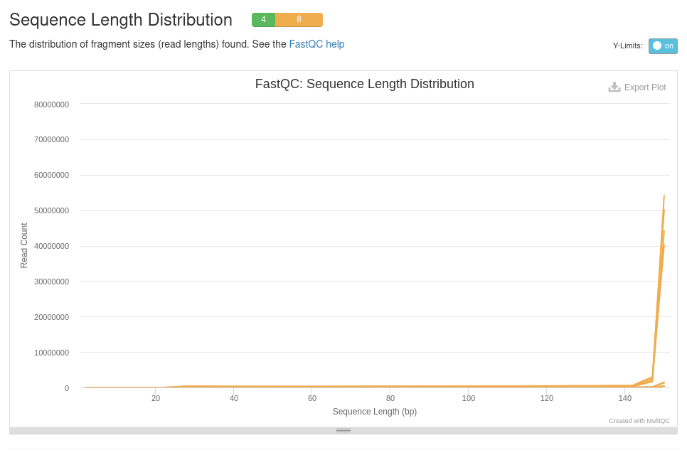

### Sequence Duplication Levels

In a diverse library most sequences will occur only once in the final set. A low level of duplication may indicate a very high level of coverage of the target sequence, but a high level of duplication is more likely to indicate some kind of enrichment bias (eg PCR over amplification). This graph shows the degree of duplication for every sequence in a library: the relative number of sequences with different degrees of duplication.

Only sequences which first appear in the first 100,000 sequences in each file are analysed. This should be enough to get a good impression for the duplication levels in the whole file. Each sequence is tracked to the end of the file to give a representative count of the overall duplication level.

The duplication detection requires an exact sequence match over the whole length of the sequence. Any reads over 75bp in length are truncated to 50bp for this analysis.

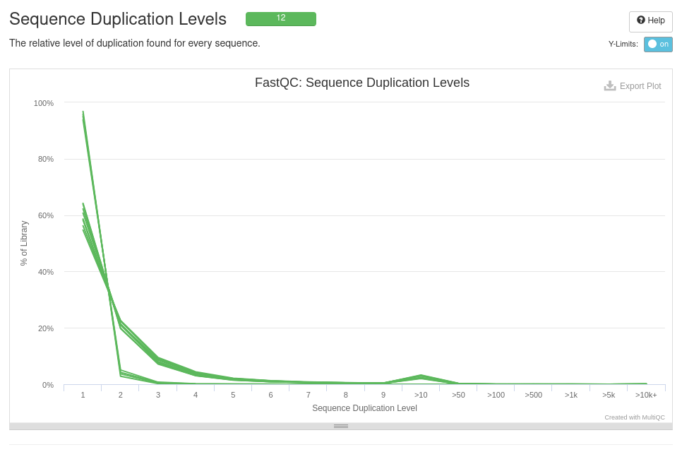

Sequence Duplication Levels

### Overrepresented sequences

A normal high-throughput library will contain a diverse set of sequences, with no individual sequence making up a tiny fraction of the whole. Finding that a single sequence is very overrepresented in the set either means that it is highly biologically significant, or indicates that the library is contaminated, or not as diverse as you expected.

FastQC lists all of the sequences which make up more than 0.1% of the total. *Caveat*:To conserve memory only sequences which appear in the first 100,000 sequences are tracked to the end of the file. It is therefore possible that a sequence which is overrepresented but doesn’t appear at the start of the file for some reason could be missed by this module.

### Adapter Content

Note that only samples with ≥ 0.1% adapter contamination are shown.

There may be several lines per sample, as one is shown for each adapter detected in the file.

The plot shows a cumulative percentage count of the proportion of your library which has seen each of the adapter sequences at each position. Once a sequence has been seen in a read it is counted as being present right through to the end of the read so the percentages you see will only increase as the read length goes on.

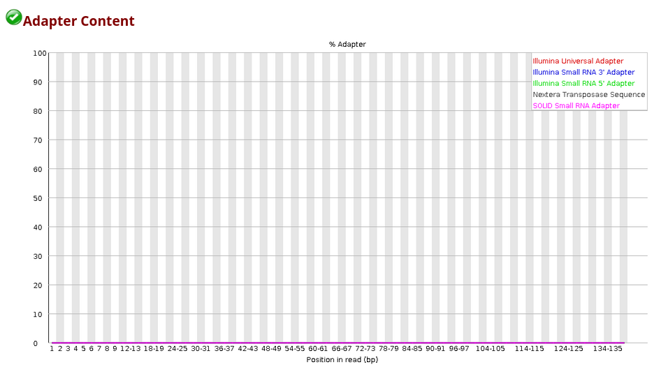

adapter_content

### Status Checks

Status for each FastQC section showing whether results seem entirely normal (green), slightly abnormal (orange) or very unusual (red).

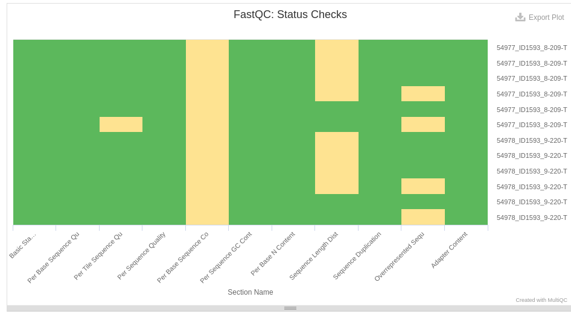

*Trimming occurs in the order which the steps are specified on the command line. It is recommended in most cases that adapter clipping, if required, is done as early as possible.*